# Ponto 6 - Teoria da Amostragem

Gabriel Agostini Orso

Data de Publicação

28 de março de 2026

# 1 Preâmbulo

**AvisoAviso**

Antes de prosseguir, o leitor deve estar ciente de que o material aqui utilizado foi elaborado com o único objetivo de estudo pessoal, portanto muitas passagens são fruto de conhecimento e interpretação pessoal. No entanto, ainda assim esse texto faz uso extensivo da literatura científica apresentada ao fim do trabalho, mas **por ser material pessoal de estudo** muitas passagens não fazem a devida citação das obras consultadas, tal qual se esperaria de trabalhos científicos.

Além isso, não foram utilizadas ferramentas de inteligência artificial como *chatGPT*, *Gemini*, *Manus* ou outras para a construção do texto. Toda a sequência lógica, exemplos, entendimentos e escrita são de responsabilidade do autor.

Com essas condições em mente, espero que esse material seja oportuno. Boa leitura.

# 2 Introdução

A Teoria da Amostragem constitui um dos pilares fundamentais da estatística aplicada, permitindo a inferência sobre populações a partir da análise de subconjuntos selecionados segundo critérios probabilísticos. Em vez de medir todos os elementos de uma população — tarefa muitas vezes inviável por limitações logísticas, econômicas ou temporais —, a amostragem permite estimar parâmetros populacionais como médias, totais e proporções com graus conhecidos de precisão. No campo da Engenharia Florestal, esse recurso é especialmente valioso, dado que os inventários florestais frequentemente abrangem grandes áreas com elevado número de indivíduos distribuídos de forma espacialmente heterogênea.

O valor da Teoria da Amostragem reside não apenas na sua base estatística, com ênfase em propriedades dos estimadores como viés e consistência, mas também em sua capacidade de guiar decisões práticas sobre o planejamento e a execução da coleta de dados. Ao lado de aspectos teóricos como o Teorema Central do Limite e as Leis dos Grandes Números, a teoria também compreende elementos operacionais como o conceito de unidade amostral, a definição de população, a intensidade da amostragem e a distinção entre censo e amostragem — todos essenciais para o desenho de uma campanha amostral eficiente e tecnicamente válida.

Além disso, a classificação dos processos amostrais segundo critérios como periodicidade, estrutura e forma de abordagem da população permite adaptar a amostragem às mais diversas realidades de campo. Inventários de uma única ocasião ou de múltiplas ocasiões, amostragem aleatória simples, estratificada, sistemática ou em múltiplos estágios, bem como métodos de área fixa ou área variável, são estratégias que compõem o repertório do engenheiro florestal no planejamento de levantamentos florestais. A escolha adequada entre essas alternativas impacta diretamente na qualidade das estimativas obtidas e na viabilidade do trabalho de campo.

Dada essa abrangência, este texto busca não apenas apresentar os fundamentos estatísticos da Teoria da Amostragem, mas também integrar os aspectos conceituais e práticos envolvidos em sua aplicação na área florestal. Parte-se, assim, da base teórica clássica, mas avançando para os componentes aplicados que orientam a estruturação de inventários florestais reais. Ao longo dos tópicos, serão discutidos os fundamentos estatísticos, os conceitos-chave de população e amostra, os diferentes tipos e métodos de amostragem, bem como os processos operacionais que permitem sua aplicação em campo com precisão e acurácia.

# 3 Fundamentação estatística

## 3.1 Definição e importância da amostragem clássica

Amostragem, ou Teoria da Amostragem, é um ramo da estatística que estuda maneiras de tirar conclusões sobre uma população sem ter que medir ou observar todos os seus elementos. Mais especificamente, a Teoria da Amostragem busca formas de selecionar subconjuntos representativos de uma população, a fim de gerar interpretações sobre suas características. A premissa central é que, a partir de uma boa amostra, é possível estimar características da população (como média, proporção, variância) com **precisão e confiabilidade**.

Embora relativamente complexa, é a fundamentação teórica da amostragem que nos dá a *garantia* de que certas propriedades são atendidas (convergência para a distribuição normal, por exemplo), e isso permite a formulação de testes de hipóteses e interpretação de resultados. Portanto o entendimento sólido da Teoria da Amostragem é crucial para não somente aplicação adequada, mas também para o desenvolvimento de novas metodologias adaptadas para novos contextos. O conhecimento dessa teoria se justifica na Ciência Florestal, pois essa sempre contribuiu nessa seara, e mesmo hoje apresenta continuamente novas propostas de amostragem para novos problemas, tal qual Machado *et al.* (2025).

O primeiro conhecimento necessário para o entendimento da teoria da amostragem é o de que existem duas teorias ou escolas estatísticas que fazem uso de amostras para inferência, a Teoria da Amostragem Clássica (TAC) e a Teoria da Pesquisa por Amostragem (TPA). A primeira é a base para pesquisas com experimentação, e a segunda é a principal utilizada em inventários como conhecemos, portanto, será a que mais será dado ênfase nesse breve ensaio.

A TAC é a linha mais tradicional e é baseada em sua essência em problemas chamados de população infinita, e, portanto, está fortemente amparada em teoremas assintóticos, como a Lei dos Grandes Números, Teoria Central do Limite, e seus consequentes estimadores assintóticos, i.e., com propriedades válidas quando $n \to \infty$. Além disso, a TAC necessariamente presume uma distribuição de probabilidade para a amostra. É dessa abordagem que são construídos os estimadores para análises de experimentos controlados, por exemplo. Veja que em experimentos controlados é presumido que as amostras obtidas provêm de uma população de tamanho desconhecido, portanto infinita, mas ainda assim são amostras.

Dessa amostra, a Teoria da Amostragem Clássica sempre busca *conhecer parâmetros de uma distribuição de probabilidade*, e graças à teoria da amostragem são normalmente os parâmetros de uma distribuição normal, a média $\mu$ e a variância $\sigma^2$. Desde a formalização das distribuições de probabilidade com as mentes de Karl Pearson, Ronald Fisher e Andrei Kolmogorov, sempre foi cultivada a ideia de que parâmetros de uma distribuição só poderiam ser verdadeiramente obtidos se todos os indivíduos daquela população fossem medidos/observados, algo virtualmente impossível em diversos contextos. Enquanto todos os indivíduos não fossem mensurados, os valores obtidos para os parâmetros seriam apenas estimativas desses, i.e., valores aproximados. Na TAC, os estimadores são obtidos principalmente a partir da teoria da verossimilhança, e portanto possuem propriedades assintóticas.

Em contrapartida, a Teoria da Pesquisa por Amostragem (TPA) não presume distribuição alguma para os dados, *i.e.*, a distribuição dos dados não precisa ser conhecida, e assume que a amostra sempre provém de uma população finita, enumerável. Por consequência disso, a maioria dos estimadores dessa linha de amostragem não possuem viés e são consistentes para qualquer tamanho de amostra $n$. Outra característica dos estimadores é que esses são construídos a partir do desenho amostral, ou seja, a forma como a amostra foi seleciona determinará o melhor estimador.

As principais quantidades de interesse ao estudar uma população são a média e o total populacional, porém outras medidas são oportunamente tratadas na teoria, como a razão entre variáveis e medidas de proporção. Para obter tais quantidades, se faz o uso de subconjuntos dessa população, chamada *amostra*, e a partir dessa amostra tais quantidades são estimadas. Um dos principais autores do ramo da TPA foi sem dúvida William Cochran com seu livro Sampling Techniques (COCHRAN, 1977), onde o autor compilou diversas técnicas e métodos de amostragem para diversos contextos.

A Tabela 1 apresenta as principais diferenças entre as duas teorias. Embora com diferenças marcantes, alguns momentos dos inventários florestais conciliarão as duas abordagens para a realização de inferências.

Tabela 1: Diferenças entre a Teoria da Amostragem Clássica e a Teoria da Pesquisa por Amostragem.

|  | População | Objeto de inferência | Pressupostos | Obtenção dos estimadores |
| --- | --- | --- | --- | --- |
| TAC | Infinita | Parâmetros de distribuições | Assume alguma distribuição | Máxima verossimilhança, Método dos Momentos, Outros. |
| TPA | Finita | Média, Variância (momentos) | Não exige conhecimento da distribuição da v.a. | A partir do desenho amostral |

Como abordado, ambas as teorias tratam da tentativa de encontrar o valor populacional, que faz uso de todos os indivíduos, conhecendo-se apenas uma fração dessa.

## 3.2 Estimadores e suas propriedades: viés, variância e consistência

Foi com esse pensamento que foram desenvolvidos os *estimadores* para as quantidades de interesse, ou, em outras palavras, aproximações para se chegar ao valor verdadeiro do parâmetro. Esse desenvolvimento trouxe consigo não apenas formulações para os estimadores, como também questionamentos como: i) o estimador aponta corretamente para o valor verdadeiro, ou ele possui *viés de estimativa*?; ii) sabendo que apenas uma amostra foi coletada, qual é a variância, ou qual a *incerteza associada a essa estimativa*?; iii) caso fossem medidos todos ou infinitos indivíduos da população (quando $n \to N$, onde $n$ é o tamanho da amostra e $N$ é o tamanho da população), esse estimador apontaria para o verdadeiro valor? Ou em outras palavras, ele é um estimador consistente? Todas essas perguntas são de extrema importância na teoria da amostragem, pois são os alicerces para a inferência estatística, muito usada em inventários florestais, e merecem ser respondidas. A seguir serão traçados pequenos ensaios a respeito das propriedades de *viés e consistência* de estimadores.

Seja $\hat\theta$ um estimador do parâmetro $\theta$. Esse parâmetro desconhecido pode ser o parâmetro de uma distribuição ou então uma medida populacional, como a média ou o total da população. $\hat\theta$ será considerado um estimador não viesado para $\theta$ se o valor esperado de $\hat\theta$ for igual a $\theta$:

$$E[\hat\theta] = \theta$$

em que $E[\cdot]$ é o operador de esperança matemática.

Essa condição é satisfeita pela maioria dos estimadores utilizados em inventários florestais. Para praticamente todos os processos (amostragem aleatória simples, estratificada, sistemática etc.), os estimadores são não viesados. Veja que, se um estimador for de fato viesado, então a condição acima não é satisfeita, e haverá um viés dado por:

$$B(\hat{\theta}) = E[\hat\theta - \theta] = E[\hat\theta] - \theta$$

em que $B(\cdot)$ representa o viés (bias) de $\hat\theta$.

Ou seja, o viés de um estimador pode ser calculado como a diferença entre o valor esperado e o verdadeiro valor do parâmetro. Para alguns casos, essa quantidade pode ser calculada analiticamente, porém, na maioria dos casos, o viés pode ser somente estimado computacionalmente. Na área florestal, um conhecido estimador viesado é o estimador de razão, que recentemente tem sido empregado para estimadores de biomassa florestal (PÉLLICO NETTO; BEHLING, 2019).

Veja ainda que um estimador pode ser assintoticamente não viesado, isto é, perde seu viés quando $n \to \infty$. Esse é o caso dos estimadores obtidos via máxima verossimilhança na Teoria da Amostragem Clássica. Um caso interessante é o estimador da variância da população, por vezes com denominador $n - 1$ ou com $n$:

$$\hat\sigma^2 = \frac{\displaystyle\sum_{i=1}^{n}(y_i-\bar y)^2}{n}
\qquad \text{ou} \qquad
s^2 = \frac{\displaystyle\sum_{i=1}^{n}(y_i-\bar y)^2}{n-1}$$

em que $\hat\sigma^2$ e $s^2$ são estimadores da variância, $y_i$ é a variável de interesse, $\bar y$ é a média amostral da variável, e $n$ é o número de observações.

No caso acima, a primeira forma é obtida ao derivar o estimador via máxima verossimilhança, portanto é um estimador assintoticamente não viesado (perde seu vício quando $n \to \infty$), ao passo que a segunda forma é obtida utilizando a TPA. Sua derivação pode ser conferida em Cochran (1977).

Para o segundo questionamento, o da variância do estimador, é necessário ter em mente a ideia geral de que variância é o segundo momento em torno da esperança:

$$V[\hat\theta] = E\left[\left(\hat\theta - E[\hat\theta]\right)^2\right]$$

em que $V[\cdot]$ é a variância do estimador.

Ou seja, essa expressão descreve como os possíveis valores do estimador $\hat\theta$ se distribuem no entorno de $E[\hat\theta]$. Nos métodos tradicionais da TAC, a variância do estimador é obtida analiticamente via máxima verossimilhança, método dos momentos ou simulação, como técnicas de *bootstrap*. Na TPA, a obtenção da variância do estimador é dependente do plano amostral, e alguns casos resultam em cálculos bastante complexos.

Naturalmente, entre dois possíveis estimadores de um parâmetro, o melhor será aquele com menor viés e menor variância, pois será tanto mais acurado quanto mais preciso. Para avaliar isso, existe uma medida que combina viés e variância de um estimador, chamada Erro Quadrático Médio (EQM):

$$\begin{aligned}
EQM[\hat\theta] &= E\left[(\hat\theta - \theta)^2\right] \\
&= E\left[(\hat\theta - E[\hat\theta] + E[\hat\theta] - \theta)^2\right] \\
&= E\left[(\hat\theta-E[\hat\theta])^2 + 2(\hat\theta - E[\hat\theta])(E[\hat\theta]-\theta) + (E[\hat\theta] - \theta)^2\right] \\
&= E\left[(\hat\theta - E[\hat\theta])^2\right] + 2.E\left[(\hat\theta - E[\hat\theta])(E[\hat\theta]-\theta)\right] + E\left[(E[\hat\theta]-\theta)^2 \right] \\
&= E\left[(\hat\theta-E[\hat\theta])^2 \right] + E\left[(E[\hat\theta] - \theta)^2 \right] \\
&= V(\hat\theta) + B(\hat\theta)^2
\end{aligned}$$

Onde $EQM[\cdot]$ é o erro quadrático médio do estimador.

Veja que a medida de EQM leva em conta tanto a variância quanto o viés do estimador. Isso é oportuno para selecionar a melhor opção de estimador para um parâmetro. É importante notar que um estimador pode ser bastante viesado, mas com pequena variância, a ponto de ter menores valores de EQM quando comparado com um estimador não viesado, porém com maior variância. Esse *trade-off* de escolher um estimador viesado, porém com menor variabilidade, é recorrentemente empregado na estatística, como no caso de métodos de regularização em modelos de regressão.

Por fim, o EQM pode ser utilizado para responder à terceira característica medida ou avaliada de um estimador: sua consistência. De acordo com o embasamento estatístico formalizado até aqui, só se saberia o real valor de um parâmetro se todos os indivíduos fossem medidos. Isso equivale a dizer que, se todos os indivíduos fossem mensurados, tanto a incerteza quanto o viés do estimador tenderiam a zero.

Na Teoria da Pesquisa por Amostragem isso é facilmente demonstrável, pois se a formulação do estimador tomar a forma da quantidade populacional quando $n \to N$, então o estimador será consistente. Já para a teoria clássica há uma dificuldade maior e requer bastante embasamento teórico. Uma definição clássica e adequada para a consistência de um estimador é a de que ele é **quadrático médio consistente** se, e somente se,

$$EQM(\hat\theta) \to 0 \quad \text{quando } n \to \infty$$

Outra forma mais fraca de consistência é a consistência em probabilidade, que testa se $V(\hat\theta) \to 0$ quando $n \to \infty$, *i.e.*, se, para todo $\epsilon > 0$,

$$P\left(|\hat\theta - \theta| > \epsilon\right) \to 0 \quad \text{quando } \quad n \enspace \xrightarrow{P} \enspace \infty$$
Onde $\xrightarrow{P}$ representa a convergência em probabilidade.

A convergência em probabilidade é atestada por meio da desigualdade de Chebyshev.

### 3.2.1 Exemplo prático

Aqui um exemplo prático é oportuno. Suponha que seja objetivo conhecer o diâmetro médio das árvores de uma floresta. A média populacional $\bar Y$ seria conhecida se fosse feita a média de todos os diâmetros da floresta, de tamanho $N$:

$$\bar Y = \frac{1}{N}\sum_{i=1}^{N} y_i$$

em que $\bar Y$ é a média populacional, $N$ é o tamanho da população e $y_i$ são os $i$-ésimos elementos da população.

Porém apenas uma fração dessa população, de tamanho $n$, é conhecida, e busca-se encontrar a melhor maneira de estimar $\bar Y$ a partir dessa amostra. Um bom candidato é utilizar a formulação:

$$\bar y = \frac{1}{n}\sum_{i=1}^{n} y_i$$

em que $\bar y$ é a média amostral e $n$ é o tamanho da amostra.

Testaremos se $\bar y$ é um estimador não viesado para $\bar Y$. Supondo que a amostra foi obtida via amostragem casual simples, e como $N$ é finito e, portanto, enumerável, então existe um conjunto finito de valores possíveis para $\bar y$. Isso caracteriza $\bar y$ como uma distribuição discreta de probabilidade.

Como $\bar y$ é discreta, sua esperança é dada por:

$$E[\bar y] = \sum_{k=1}^{\binom{N}{n}} \bar y_k\, p(\bar y_k)$$

em que $k$ é o índice da possível amostra, isto é, $k = 1, 2, \ldots, \binom{N}{n}$, e $p(\bar y_k)$ é a probabilidade de observar $\bar y_k$.

Como todas as amostras são igualmente prováveis, isto é,

$$p(\bar y_k) = \frac{1}{\binom{N}{n}} \quad \forall \enspace k \in 1, 2, \ldots, \binom{N}{n}$$

,então

$$E[\bar y] = \frac{1}{\binom{N}{n}}\sum_{k=1}^{\binom{N}{n}} \bar y_k$$

A propriedade de não-viesado é aferida ao estimador se $E[\bar y] = \bar Y$.

**Prova**

Quer-se mostrar que $E[\bar y] = \bar Y$:

$$E[\bar y] = \frac{1}{\binom{N}{n}} \sum_{k=1}^{\binom{N}{n}} \frac{y_{k1}+y_{k2}+\cdots+y_{kn}}{n}$$

Note que $y_{ki}$ é a $i$-ésima unidade amostral da *$k$-ésima possível amostra*. Expandindo o somatório, tem-se que cada unidade amostral estará presente em exatas $\binom{N-1}{n-1}$ amostras. Assim,

$$\begin{aligned}
E[\bar y] &= \frac{1}{\binom{N}{n}}\frac{\binom{N-1}{n-1}(y_1+y_2+\cdots+y_N)}{n} \\
&= \frac{1}{\frac{N!}{n!(N-n)!}}\frac{\frac{(N-1)!}{(n-1)!(N-n)!}\displaystyle\sum_{i=1}^N y_i}{n}\\
&=\frac{n!(N-n)!}{N!} \frac{(N-1)!}{(n-1)!(N-n)!n} \displaystyle\sum_{i=1}^N y_i \\
&= \frac{n(n-1)!(N-1)!}{N(N-1)!(n-1)!n} \displaystyle\sum_{i=1}^N y_i \\
\end{aligned}$$

$$E[\bar y] = \frac{1}{N}\sum_{i=1}^{N} y_i = \bar Y$$

Veja, portanto, que a esperança do estimador $\bar y$ é o próprio valor populacional. Isso implica que, em média, o estimador aponta para a direção correta. Essa propriedade é muito importante e buscada entre estimadores. Veja ainda que $\bar y$ é construído a partir do desenho amostral, da maneira como a amostra foi obtida.

Outra propriedade importante que o estimador da média possui é a da consistência. Como já definido, um estimador é considerado consistente quando seu valor atinge exatamente o valor paramétrico quando $n = N$. Para o estimador da média populacional na amostragem casual simples, isso é facilmente observado:

$$\bar y = \frac{1}{n}\sum_{i=1}^{n} y_i \quad
\xrightarrow[n\to N]{} \quad
\frac{1}{N}\sum_{i=1}^{N} y_i = \bar Y$$

O que implica que o estimador tende ao valor populacional conforme a amostra cresce.

## 3.3 Teorema Central do Limite (TCL)

Atestadas as principais características e condições para a obtenção e escolha de bons estimadores, surge a necessidade de solução de outro problema: a inferência estatística. Como os estimadores são variáveis aleatórias e, portanto, incertos por natureza, é sempre desejado saber *quão* variável é a estimativa ou qual o intervalo de valores mais prováveis de ocorrência.

Isso é respondido pelo uso de intervalos de confiança, ou inferência intervalar, mas isso necessariamente exige o uso de uma distribuição de probabilidade. Porém, a TPA não demanda da distribuição dos dados, e calcula as quantidades de interesse puramente do desenho amostral. Esse é o ponto de conciliação entre as duas teorias, pois é onde a TPA faz uso de um teorema estatístico para inferir uma distribuição apropriada para as quantidades estimadas: o Teorema Central do Limite (TCL).

O TCL é um resultado estatístico construído desde 1733 e formalizado na década de 1930, que foi abraçado pela teoria da amostragem e garante a criação de estimadores de média e variância para variáveis aleatórias de qualquer tipo de distribuição de probabilidade.

Em termos gerais, o TCL garante que, para uma sequência de variáveis aleatórias independentes e identicamente distribuídas (i.i.d.), a distribuição da média padronizada se aproxima de uma normal padrão quando $n \to \infty$. Seja $X_1, X_2, \ldots, X_n$ uma sequência de variáveis aleatórias i.i.d. com média $\mu$ e variância $\sigma^2 < \infty$, então:

$$\frac{\bar X_n - \mu}{\sigma/\sqrt{n}} \xrightarrow{\mathcal D} \mathcal N(0,1)$$

em que $\xrightarrow{\mathcal D}$ representa convergência em distribuição quando $n \to \infty$, e $\bar X_n$ é a média da sequência de variáveis aleatórias.

O TCL funciona porque faz uso da Lei dos Grandes Números estabelecida na matemática, principalmente a Lei Forte de Kolmogorov, que atesta que, para $X_1, X_2, \ldots, X_n$ com $E[X_i]=\mu$ e $Var[X_i] < \infty$, então

$$\bar X_n = \frac{1}{n}\sum_{i=1}^{n}X_i \xrightarrow{\text{q.c.}} \mu$$

em que $\xrightarrow{\text{q.c.}}$ representa convergência quase certa.

Pela Lei Forte de Kolmogorov, a média de uma sequência de variáveis aleatórias i.i.d. irá quase certamente convergir assintoticamente para a média paramétrica daquela variável, **sem precisar ser conhecida a distribuição de probabilidade da variável**. Esse é um ponto importantíssimo para a teoria da amostragem, pois possibilita que o TCL seja utilizado nas mais diversas ocasiões e tipos de medidas que se deseja mensurar ou observar.

A partir do resultado do TCL, uma transformação mais usual e que já carrega muita da teoria da amostragem resulta na seguinte distribuição da média $\bar X_n$:

$$\bar X_n \sim N\left(\mu, \frac{\sigma^2}{n}\right)$$

em que $\mu$ é a média da distribuição, e $\sigma^2/n$ é a variância da distribuição.

Pelo resultado acima, existe a **garantia** de que, ao selecionar uma amostra de uma população e calcular sua média, então essa média seguirá assintoticamente uma distribuição normal com tais parâmetros. Aqui já fica clara a relação do TCL com fórmulas comumente utilizadas na amostragem, como a variância da média amostral da amostragem aleatória simples para populações infinitas e finitas:

$$s^2_{\bar X} =
\begin{cases}
\dfrac{s^2}{n}, & \text{se população infinita} \\
\dfrac{s^2}{n}\dfrac{N-n}{N}, & \text{se população finita}
\end{cases}$$

em que $s^2_{\bar X}$ é a variância estimada da média amostral, $s^2$ é a variância estimada, e $n$ e $N$ são os tamanhos da amostra e da população, respectivamente.

Em verdade, a variância da média para populações finitas do exemplo acima é calculada a partir do plano amostral. Esse exemplo torna clara a origem da dicotomia entre populações finitas e infinitas: se for assumida população infinita, então os estimadores vêm da Teoria da Amostragem Clássica; mas, se for assumida população finita, então os estimadores vêm da Teoria da Pesquisa por Amostragem. Conforme a amostra cresce, ambas as teorias convergem.

## 3.4 Inferência estatística com base em amostras

Com a distribuição de probabilidade da média amostral bem definida, é possível realizar inferências e testes de hipótese, como calcular o intervalo que contém 95% da densidade da distribuição. Porém, antes é necessário realizar uma pequena modificação, que é um ponto-chave da teoria da amostragem e nos traz de volta à realidade de que estamos trabalhando com uma amostra, e não de forma assintótica.

A convergência para a normal padrão, resultado do TCL, só é válida quando a variância populacional $\sigma^2$ é conhecida — e isso raramente acontece. Em contrapartida, o que se tem normalmente é uma variância amostral dada por:

$$s^2 = \frac{\sum_{i=1}^{n}(X_i-\bar X)^2}{n-1}$$

Ao substituir $\sigma$ por $s$, o termo

$$\frac{\bar X_n-\mu}{s/\sqrt n}$$

em vez de

$$\frac{\bar X_n-\mu}{\sigma/\sqrt n}$$

não seguirá exatamente uma distribuição normal, mas sim uma *distribuição $t$ de Student* com $n-1$ graus de liberdade. Isso ocorre porque $s^2$ introduz uma variabilidade extra, pois a própria variância é incerta, e a distribuição $t$ acomoda essa incerteza adicional, especialmente quando $n$ é pequeno. A distribuição $t$ é mais pesada nas caudas, corrigindo a subestimativa do erro padrão que ocorreria se $s$ fosse usado como $\sigma$. Não por acaso, a distribuição $t$ de Student é chamada de distribuição da amostra, e ela é usada no lugar da distribuição normal justamente nesses casos, quando não é possível utilizar uma normal pois σ não é conhecido.

Feita a correção da distribuição amostral, os métodos de inferência e testes de hipótese seguem similares, como, por exemplo, o erro de amostragem e os limites do intervalo de confiança:

$$E = t_{\alpha/2;\,n-1}\, s_{\bar X}$$

$$E\% = \frac{t_{\alpha/2;\,n-1}\, s_{\bar X}}{\bar X_n}\cdot 100$$

$$LI = \bar X_n - t_{\alpha/2;\,n-1}\, s_{\bar X}$$

$$LS = \bar X_n + t_{1-\alpha/2;\,n-1}\, s_{\bar X}$$

em que $E$ e $E\%$ são os erros de amostragem absoluto e relativo, $LI$ e $LS$ são os limites inferior e superior do intervalo de confiança, e $t$ é o quantil da distribuição $t$ de Student para a devida probabilidade e grau de liberdade.

# 4 Conceitos básicos

Apresentadas as fundamentações teóricas da teoria da amostragem, é possível tratar agora dos conceitos básicos empregados na amostragem. Esses conceitos são importantes para poder, por exemplo, delimitar o que é a população, qual a extensão da amostragem (intensidade), ou como selecionar uma amostra de forma que respeite os fundamentos apresentados anteriormente.

## 4.1 População

O primeiro conceito que deve ser entendido é o de população e amostra. População é o conjunto de todos os indivíduos sobre os quais se deseja medir ou observar alguma característica, representado pela letra latina maiúscula $N$. Uma população deve ser sempre bem definida, para que qualquer interpretação sobre essa característica medida seja adequada.

Alguns autores trazem diversas especificações e quesitos que uma população deve atender, como:

1. os indivíduos da população são da mesma natureza;
2. os indivíduos da população diferem com respeito a uma característica típica ou atributo chamado variável.

Além desses quesitos, também é importante perceber que uma população normalmente possui um recorte espacial (há uma delimitação espacial da população) e um recorte temporal (uma população pode variar no tempo). Na notação matemática, o número de indivíduos da população é normalmente representado pela letra $N$ maiúscula.

Um exemplo de população pode ser o conjunto de todas as árvores existentes em um determinado talhão florestal em um determinado ano. Todos os resultados e interpretações tomadas desses indivíduos são válidas para esse talhão apenas, para aquele ano especificado.

## 4.2 Amostra (maneiras de selecionar)

Já a amostra, por sua vez, é definida como um subconjunto dessa população, ou apenas parte dessa população, representada pela letra latina minúscula $n$. Ainda assim, por mais que seja apenas uma amostra, essa precisa representar toda a população de que fez parte. É evidente que, se uma amostra precisa representar toda a população, ela precisa ser considerada *representativa*, pois normalmente só será extraída uma única amostra da população, de um total de $\binom{N}{n}$ amostras possíveis:

$$\binom{N}{n} = \frac{N!}{n!(N-n)!}$$

Dessa lógica surgem os questionamentos sobre como selecionar adequadamente uma amostra. Embora existam diversas maneiras, um método garantido de ser representativo, e que atende às exigências da teoria estatística, é a seleção aleatória dos indivíduos que irão compor a amostra, pois isso implicará em amostras *independentes e identicamente distribuídas*. Essa aleatorização pode sofrer restrições a depender do caso (por exemplo, na amostragem estratificada), mas é apenas a seleção aleatória que garante o cumprimento dos pressupostos estatísticos.

Nesse contexto, Péllico Netto e Brena (1997) sugerem duas condições para a seleção de uma amostra:

1. a seleção deve ser um processo inconsciente;
2. indivíduos inconvenientes não podem ser substituídos.

Note que a inclusão de influências subjetivas na escolha da amostra, e a substituição de indivíduos, também comprometem uma escolha aleatória, pois haverá claro viés de preferência de alguns indivíduos em detrimento de outros. Na notação matemática, a quantidade de indivíduos da amostra é normalmente representada pela letra $n$ minúscula, e é evidente que $n \leq N$, pois não é possível selecionar amostra maior que a população.

## 4.3 Unidade amostral

Com a definição do que é uma amostra e de uma população, fica implícito o entendimento de que a amostra é constituída de elementos únicos e indivisíveis para aquele atributo sendo mensurado, chamados de *unidades amostrais* (UA). As unidades amostrais são os menores elementos, ou elementos unitários, que compõem tanto a amostra quanto a população.

Na ciência florestal, as unidades amostrais podem ser tanto árvores quanto parcelas de inventário florestal, sendo essas últimas mais comuns. Veja que normalmente o objetivo de um inventário florestal é a estimativa de uma medida por unidade de área, portanto as unidades amostrais são comumente porções do espaço físico daquela população. Na notação matemática, uma unidade amostral é representada pelo índice $i$ associado à variável aleatória medida na amostra, como $X_i$, representando a medida $X$ na $i$-ésima unidade amostral.

Uma condição adicional para a definição de unidades amostrais é a de que todas as unidades amostrais precisam ser independentes e identicamente distribuídas (*i.i.d.*), pois isso é exigência da Lei Forte de Kolmogorov, que fundamenta o Teorema Central do Limite. Em outras palavras, uma unidade amostral não pode fornecer informações sobre outra unidade amostral, e todas precisam possuir a mesma chance de seleção (ao menos dentro de cada estrato) e a mesma distribuição de probabilidade, seja ela qual for.

## 4.4 Censo e amostragem

Com a definição do que é uma amostra e suas unidades amostrais constituintes, a próxima definição é qual seria o tamanho dessa amostra. Tal explicação pode se iniciar pelos extremos.

O que aconteceria se a amostra fosse composta por apenas uma UA, isto é, $n = 1$? Nesse caso, a teoria da amostragem não seria aplicável, pois com apenas uma amostra não é possível determinar quão variável é a população. O denominador do estimador da variância $(n-1)$ seria igual a zero e, portanto, resultaria em uma indeterminação.

Por outro lado, a seleção de toda a população $(n = N)$ resultaria em um censo, onde todos os indivíduos são mensurados. Se esse for o caso, então não se terá uma estimativa da quantidade populacional, mas sim seu valor verdadeiro. Matematicamente, isso implicará que o componente $\left(\frac{N-n}{N}\right)$ da variância da média amostral será igual a zero, o que resultará em $s^2_{\bar X}=0$; logo, não haverá incerteza sobre a estimativa do parâmetro, ele deixará de ser incerto.

Censos são, diversas vezes, impraticáveis na ciência, dado o alto custo e tempo para medir toda a população de interesse, mas são extremamente bem-vindos quando sua realização é possível. Na área florestal, censos são necessários em planos de manejo florestal sustentáveis na Amazônia, mas a população de interesse normalmente se reduz às árvores com pelo menos 30 cm de diâmetro, o que diminui em muito o esforço de campo e o tempo de medição, muito embora toda a área ainda precise ser visitada.

Qualquer tamanho de amostra que esteja entre $1 < n < N$ será uma amostra que fornecerá *tanto uma estimativa da média ou quantidade de interesse quanto sua variabilidade*, desde que a amostra seja representativa. Mesmo sem uma definição formal, faz sentido também que, quanto maior o tamanho da amostra, menor a incerteza da estimativa.

## 4.5 Intensidade de amostragem

Assim, uma pergunta que se apresenta é: qual o tamanho adequado da amostra? Historicamente, o tamanho da amostra é expresso como intensidade amostral, matematicamente denotada por $f$:

$$f = \frac{n}{N}$$

em que $f$ é a fração amostral, isto é, a fração da população amostrada.

A decisão do tamanho da amostra pode ser definida de duas formas:

1. definição da intensidade em função da precisão exigida;
2. definição da intensidade em função do tempo e dos recursos disponíveis.

O primeiro caso delimita um erro máximo admitido na precisão da estimativa. Mesmo que sem definição formal, é coerente pensar que, quanto maior a fração amostral, menor é a incerteza em torno do valor paramétrico. Sabendo que o erro amostral é uma função da variância estimada e do valor da distribuição $t$ de Student para um dado $n$, a obtenção do tamanho de amostra adequado pode ser derivada resolvendo a equação do estimador do erro padrão para $n$. O exemplo abaixo se refere à estimativa da intensidade amostral adequada para o processo de amostragem casual simples.

$$E = t_{\alpha/2;\,n-1}\, s_{\bar X}$$

$$E^2 = t^2_{\alpha/2;\,n-1}\, s^2_{\bar X}$$

Como $s^2_{\bar X}$ pode ser reescrito em função da variância da amostra, então:

$$s^2_{\bar X} = \frac{s^2}{n}\frac{N-n}{N} = \frac{s^2}{n}\left(1 - \frac{n}{N}\right)$$

E, portanto,

$$\begin{aligned}
t^2 s^2_{\bar X}
&= t^2\frac{s^2}{n}\left(1-\frac{n}{N}\right) \\
&= \frac{t^2 s^2}{n} - \frac{t^2 s^2}{N}
\end{aligned}$$

logo,

$$\frac{t^2 s^2}{n} = t^2 s^2_{\bar X} + \frac{t^2 s^2}{N}$$

Assim,

$$n = \frac{t^2 s^2}{t^2 s^2_{\bar X} + \frac{t^2 s^2}{N}} = \frac{t^2 s^2}{E^2 + \frac{t^2 s^2}{N}}$$

Portanto, ao especificar um erro amostral $E$ e uma variância $s^2$, é possível descobrir o número de unidades amostrais necessárias para atingir tal erro. Mais costumeiramente, esse erro pode ser expresso em porcentagem no entorno da média. Nesse caso, o erro absoluto pode ser encontrado por:

$$E^2 = t^2\left(LE\cdot \bar X_n\right)^2$$

em que $LE$ é o limite de erro admitido, como $0{,}10$ (10%). Evidentemente, processos de amostragem mais complexos, como amostragem estratificada ou por conglomerado, terão diferentes cálculos e diferentes maneiras de estabelecer o tamanho da amostra.

A segunda forma de determinação da intensidade amostral é em função da quantidade de recursos disponíveis. Esses recursos podem ser tanto financeiros quanto de tempo, humanos ou materiais.

Embora não seja uma abordagem estatística, é muitas vezes o fator mais importante para a definição do número de amostras a serem medidas ou observadas. Um método prático é por meio da função de custo, que primeiramente estabelece quais são os custos fixos $(C_0)$ e variáveis $(C_1)$ da amostragem, onde custos fixos são aqueles que independem do tamanho da amostra medida, e custos variáveis são aqueles que crescem conforme aumenta o número de UA.

$$C_t = C_0 + n\, C_1$$

$$n = \frac{C_t - C_0}{C_1}$$

em que $C_t$ é o custo total da amostragem, $C_0$ é o custo fixo e $C_1$ é o custo variável, ou custo por unidade amostral mensurada.

## 4.6 Erros de amostragem

Outros comentários podem ainda ser feitos sobre os erros de amostragem. O erro total que uma amostragem comete é a diferença entre a média amostral e a média paramétrica:

$$\mathcal E = \mu - \bar X_n$$

em que $\mathcal E$ é o erro total de amostragem, $\mu$ é a média paramétrica e $\bar X_n$ é a média amostral.

Esse erro de amostragem pode ser decomposto em dois tipos de erro (COCHRAN, 1977): erro amostral e erro não amostral. O primeiro está inteiramente relacionado com o fato de uma amostra não contemplar toda a informação da população, *i.e.*, é a incerteza associada ao fator de somente uma fração da população ser conhecida.

Os erros não amostrais não possuem relação com amostras ou com o processo amostral. De forma independente disso, os erros não amostrais se referem a erros de medição, erros dos aparelhos de medição, erros de operação, erros de registro de informações, entre outros. Note que esses erros podem acontecer mesmo em caso de censo.

Apenas o primeiro tipo de erro é de fácil mensuração, pois é expresso pelo erro obtido da amostragem. O segundo não possui fórmulas ou quantidades de fácil observação. Ainda assim, ambos podem ser abordados: o primeiro aumentando o tamanho da amostra, e o segundo por meio de aferição, treinamento e constante supervisão do trabalho realizado. Há um ramo de trabalho chamado *controle estatístico de qualidade (CEQ)* que trata de tais erros e traça métodos para minimizar sua ocorrência.

## 4.7 Precisão e acuracidade

Junto dos erros de amostragem, a literatura da área comumente conceitua precisão e acuracidade de uma amostragem. A precisão está ligada ao erro padrão de estimativa da média amostral, sem considerar a magnitude dos erros não amostrais. Ela se refere ao tamanho dos desvios da amostra em relação à média estimada $\bar X_n$.

Já a acuracidade expressa o tamanho dos desvios da estimativa amostral em relação à média paramétrica, ou da população $\mu$, e isso inclui os erros não amostrais. É a acuracidade da estimativa amostral que realmente interessa em um inventário florestal, porém essa é de difícil estimativa e, portanto, a precisão é mais facilmente controlada.

# 5 Classificação da amostragem

Embora a teoria da amostragem seja disciplina da estatística, seu uso é feito, sobretudo, por outras áreas da ciência, o que reflete em diversas situações e condições para compor uma amostragem ou até mesmo um inventário florestal. Ao longo do tempo, várias dessas condições foram compiladas para o que hoje é tratado na teoria da amostragem como classificação, estrutura e organização operacional de amostragens.

Note que esse ramo da teoria não é fruto de métodos estatísticos, mas influencia diretamente a abordagem estatística adequada para análise. É o caso de amostras aleatórias simples e estratificadas, por exemplo, onde cada uma possui estimadores apropriados para seu caso.

Passados os rigores estatísticos da teoria da amostragem, existem ainda outros tópicos que compõem a teoria, mas que não estão relacionados inteiramente com métodos estatísticos: são a classificação, a estrutura e a organização operacional de um inventário.

## 5.1 Periodicidade

A primeira classificação de uma amostragem, e mais especificamente de um inventário florestal, é quanto à periodicidade. Este pode ser de uma única ocasião ou de múltiplas ocasiões.

A amostragem de uma ocasião é planejada para ocorrer uma única vez, isto é, não há pretensão de voltar para a mesma área novamente. Operacionalmente, isso implica instalação mais simplificada de parcelas (parcelas temporárias) e de infraestrutura para realização do inventário florestal. Para o processamento estatístico, esse é o cenário mais simples.

O segundo caso, de múltiplas ocasiões, exige atenção desde a etapa de planejamento, pois prevê o retorno periódico à mesma área de estudo da primeira ocasião, e potencialmente às mesmas parcelas de inventário. Os objetivos principais ao realizar inventários de múltiplas ocasiões são:

- estimar quantidades e características da floresta presentes na primeira ocasião;
- estimar quantidades e características da floresta presentes na segunda ocasião;
- estimar mudanças ocorridas na floresta entre as duas ocasiões.

Péllico Netto e Brena (1997) tratam o inventário florestal de múltiplas ocasiões de quatro formas distintas, chamadas de inventários florestais contínuos:

- **Amostragens Independentes (AI)** – uma nova amostra completamente nova e independente da primeira é realizada na segunda ocasião. Todas as unidades amostrais são independentes e temporárias em cada ocasião;
- **Amostragem com Repetição Total (ART)** – as unidades amostrais medidas na primeira ocasião são completamente remedidas na segunda ocasião, bem como em todas as ocasiões sucessivas;
- **Amostragem Dupla (AD)** – na segunda ocasião apenas uma parte das unidades amostrais tomadas na primeira ocasião é remedida;
- **Amostragem com Repetição Parcial (ARP)** – na segunda ocasião, parte das unidades amostrais da primeira ocasião é remedida e novas unidades temporárias são tomadas na população.

Essas combinações de remedições de parcelas já estabelecidas ou medição de novas parcelas resultam em três conjuntos de unidades amostrais:

- $m$ – o grupo de unidades amostrais permanentes que é remedido em todas as ocasiões;
- $u$ – o grupo de unidades amostrais temporárias que é medido somente na primeira ocasião;
- $n$ – o grupo de novas unidades amostrais temporárias que é medido somente na segunda ocasião.

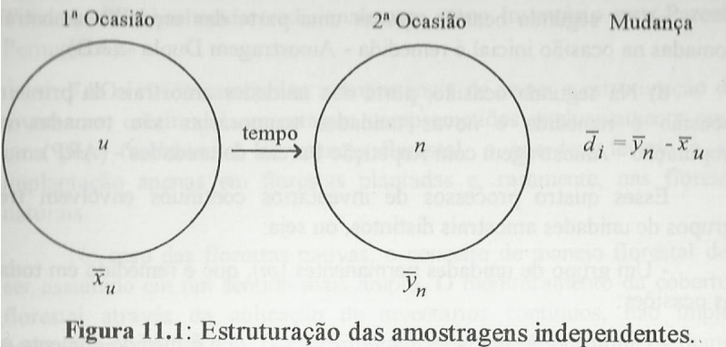

Amostragem independente.

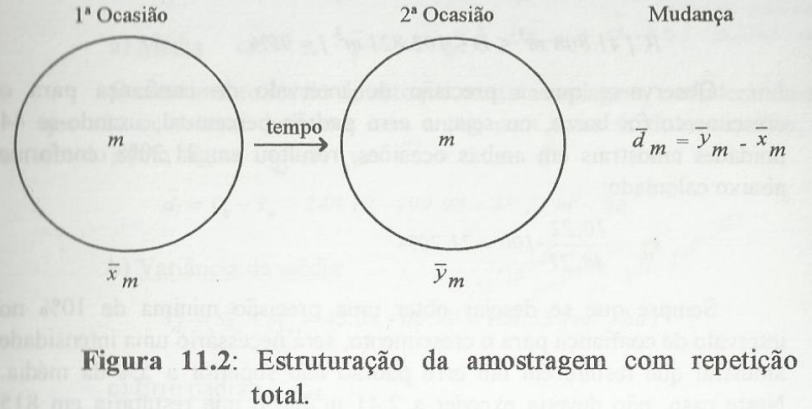

Amostragem com repetição total.

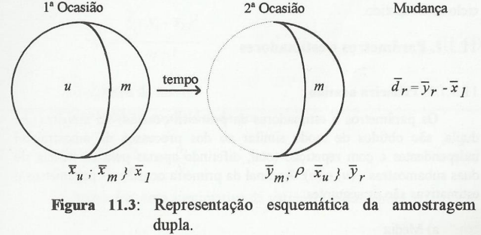

Amostragem dupla.

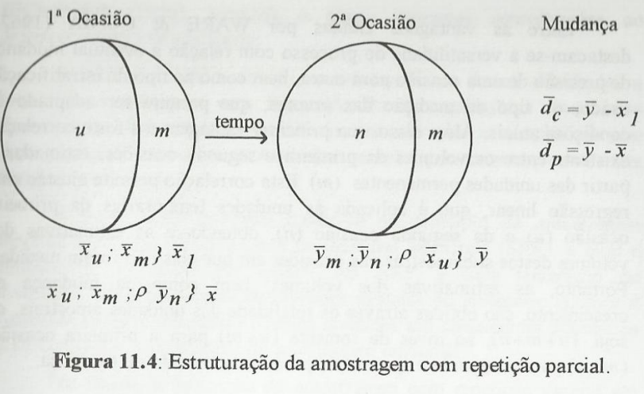

Amostragem com repetição parcial.

Fonte: Péllico Netto & Brena (1997)

Cada combinação de repetição apresentada acima resulta em estimadores próprios para obtenção não só das estimativas em cada ocasião, mas também para estimar as diferenças entre ocasiões. Operacionalmente, a complexidade de execução aumenta, pois é necessário o planejamento e a delimitação de parcelas que serão revisitadas futuramente; portanto, estas devem ser georreferenciadas e construídas com material adequado para resistir à ação do tempo.

## 5.2 Estrutura

Além da classificação da periodicidade de execução de um inventário florestal, existem ainda classificações sobre a disposição das parcelas de inventário (ou amostras, de maneira geral) em campo, chamada de classificação quanto à estrutura da amostragem. Uma amostragem ou inventário pode ter suas unidades amostrais dispostas de maneira aleatória, sistemática ou mista.

### 5.2.1 Amostragem aleatória

O emprego da amostragem aleatória é a forma de garantir que as formulações desenvolvidas na teoria estatística ocorram na prática. Por amostragem aleatória entende-se que a seleção das UA será realizada por algum critério probabilístico, que pode ser dividido em duas formas:

1. amostragem irrestrita ou inteiramente aleatória;
2. amostragem restrita.

No primeiro caso, todas as UA têm a mesma probabilidade de seleção. Isto é, se existem $N$ possíveis unidades amostrais na população, então a probabilidade de a $i$-ésima unidade amostral ser selecionada é:

$$P(I=i) = \frac{1}{N}, \qquad \forall \forall i \in \{1,2,\ldots,n\}$$

Um ponto importante da amostragem irrestrita é que todas as UAs possuem a mesma probabilidade de seleção. Na prática, somente um tipo de inventário possui tal propriedade: a amostragem aleatória simples.

Todos os demais processos de amostragem possuem algum tipo de restrição ou variação na probabilidade de seleção de UAs, o que caracteriza um processo de amostragem restrita. É dessa forma que são analisadas as amostragens estratificadas ou em múltiplos estágios. Um exemplo de probabilidade condicional em amostragem estratificada é:

$$P(I=i\mid E=e)=\frac{1}{N_e},
\qquad \forall i \in \{1,2,\ldots,n_e\},
\quad \forall e \in \{A,B\}$$

em que $N_e$ e $n_e$ representam o número total da população e o tamanho da amostra no $e$-ésimo estrato.

### 5.2.2 Amostragem sistemática

Outra forma de alocar ou organizar uma amostra é de maneira sistemática. Tal arranjo é bastante oportuno na prática, pois garante um recobrimento homogêneo de toda a área de estudo, de forma que não existam regiões não amostradas. Além disso, o espaçamento regular entre parcelas traz grande benefício para a operacionalização do inventário, pois o deslocamento na floresta se torna mais rápido e direto, e os pontos de apoio passam a ser mais bem localizados.

Entretanto, a alocação sistemática implica que, no momento em que se conhece a localização de uma parcela, todas as demais já serão conhecidas. Isso fere a condição necessária de variáveis independentes. Além disso, não há aleatoriedade na seleção das unidades amostrais, o que também fere um pressuposto importante.

Uma tática frequentemente utilizada para contornar essa situação é o sorteio aleatório da posição da primeira parcela dessa malha regular. Uma vez que a localização da primeira parcela é incerta, também a localização das demais parcelas será incerta na área, o que retornaria à condição de aleatoriedade das unidades amostrais.

### 5.2.3 Amostragem mista

Uma terceira forma de alocar parcelas ou unidades amostrais na população é de maneira mista, isto é, combinando alocação aleatória com alocação sistemática. Essa combinação é oportuna em alguns inventários, como na amostragem em múltiplos estágios, onde frequentemente o primeiro estágio é sistemático e o segundo estágio é aleatório.

## 5.3 Abordagem da população

Definida a teoria sobre a alocação e seleção de amostras, chamada de classificação quanto à estrutura da amostragem, é oportuno tratar das diferentes formas e tamanhos que uma unidade amostral pode assumir. Na ciência florestal, a forma das parcelas de inventário pode afetar os resultados do processamento, e o estudo e definição dessas é chamado de métodos de amostragem.

### 5.3.1 Métodos de amostragem

Ao método de amostragem compete a delimitação de uma unidade amostral. Na ciência florestal, existem dois grandes métodos de amostragem: área fixa e área variável, e cada um desses possui estimadores próprios.

#### 5.3.1.1 Área fixa

No método de área fixa, todas as unidades amostrais possuem a mesma forma, seja ela normalmente quadrada, retangular ou circular. É o caso mais simples e fácil de ser analisado, pois, ao ter o mesmo tamanho, as probabilidades de seleção das parcelas são sempre as mesmas.

#### 5.3.1.2 Área variável

Nos métodos de área variável, desenvolvidos especificamente para a área florestal, propõe-se que as parcelas de inventário possuam tamanho proporcional a algum atributo das árvores, o que fundamentalmente implica que as árvores possuem probabilidade de seleção proporcional ao tamanho (PPT). São os casos da amostragem pelo método de Bitterlich, Prodan, Strand e 3-P de Grosenbaugh, por exemplo.

Uma maneira simples de incluir probabilidade proporcional ao tamanho em inventários é definir, por exemplo, uma parcela circular com 5 metros de raio e medir todas as árvores com pelo menos 10 cm de DAP. No mesmo ponto central, acrescentam-se mais 3 metros de raio e medem-se todas as árvores com pelo menos 20 cm de DAP. Acrescentam-se mais 2 metros de raio e medem-se todas as árvores com pelo menos 30 cm de DAP.

No exemplo acima, fica claro que árvores maiores são medidas em parcelas maiores e, portanto, possuem maior probabilidade de seleção: probabilidade proporcional ao tamanho.

### 5.3.2 Processos de amostragem

Com a forma e o tamanho da unidade amostral definidos, usa-se agora a teoria acerca das estruturas de alocação das unidades amostrais juntamente com os métodos de amostragem, e são criados os processos de amostragem. Tais processos são compilações ou modelos de amostragens bem definidos na literatura e podem seguir a seguinte estrutura, conforme Péllico Netto e Brena (1997).

Para inventários de uma única ocasião, os processos se classificam em:

- **Aleatório**
  - Aleatório irrestrito
    - Amostragem inteiramente aleatória
  - Aleatório restrito
    - Amostragem estratificada
    - Amostragem em dois estágios
    - Amostragem em múltiplos estágios
- **Sistemático**
  - Único estágio
  - Múltiplos estágios
- **Misto**
  - Amostragem em grupos ou conglomerados
  - Amostragem sistemática com múltiplos inícios aleatórios

Para processos de múltiplas ocasiões, podem ser agrupados como:

- amostragens independentes;
- amostragem com repetição total;
- amostragem dupla;
- amostragem com repetição parcial.

### 5.3.3 Sistemas de amostragem

Por sistema de amostragem entende-se um conjunto de processos e/ou métodos de amostragem, geralmente estruturados integradamente para aplicação a uma determinada situação ou área previamente especificada.

Esses sistemas geralmente são concebidos para o caso de monitoramento de uma população, em que podem ser integrados três ou mais processos de amostragem, visando auferir da população a ser amostrada maior eficiência, maior flexibilidade e menor custo operacional em sua aplicação prática.

No plano conceitual, definições como população, unidade amostral, intensidade de amostragem e tipos de erro se mostram indispensáveis para o planejamento de campanhas de coleta de dados. Já a classificação da amostragem — quanto à periodicidade, estrutura, abordagem e método — demonstra a diversidade de estratégias disponíveis ao profissional da área florestal, permitindo adaptar o processo amostral às peculiaridades ecológicas, operacionais e econômicas de cada situação.

Assim, mais do que um conjunto de fórmulas, a teoria da amostragem oferece um arcabouço lógico e técnico que sustenta a tomada de decisões confiáveis em contextos complexos. O seu domínio é condição essencial para a elaboração de inventários precisos, eficientes e cientificamente robustos, consolidando seu papel como componente fundamental do manejo florestal sustentável.

# 6 Conclusão

A Teoria da Amostragem representa um dos instrumentos mais importantes da estatística aplicada, especialmente no contexto da Engenharia Florestal, onde a necessidade de estimar parâmetros de grandes populações com recursos limitados é uma constante. Ao longo deste texto, buscou-se apresentar não apenas os fundamentos estatísticos da teoria, mas também os conceitos essenciais, os tipos e classificações de amostragem, bem como suas implicações práticas na estruturação de inventários florestais.

A distinção entre as abordagens clássica e da pesquisa por amostragem fornece o alicerce teórico para compreender os diferentes regimes de inferência adotados, evidenciando que a escolha do referencial estatístico está intimamente ligada à estrutura da população e ao objetivo do levantamento. A noção de estimadores e suas propriedades — como viés, variância, erro quadrático médio e consistência — revela o rigor necessário ao se fazer inferência a partir de uma amostra. Neste sentido, o Teorema Central do Limite emerge como elemento central ao conectar os domínios probabilístico e inferencial da amostragem.

# 7 Bibliografia

COCHRAN, W. G. *Sampling techniques*. John Wiley & Sons, 1977.

MACHADO, H. A. et al. Aboveground biomass and carbon stocks in subtropical forests. *Ecological Indicators*, v. 172, 2025.

PÉLLICO NETTO, S.; BEHLING, A. Additivity of tree biomass components using ratio estimates. *Anais da Academia Brasileira de Ciências*, v. 91, n. 3, 2019.

PÉLLICO NETTO, S.; BRENA, D. A. *Inventário florestal*. Curitiba, 1997. 316 p.

QUEIROZ, W. T. *Amostragem em Inventário Florestal*. Belém, PA: EDUFRA, 2012. 441 p.

# 8 Conteúdos adicionais (Primeiras ideias do ponto)

Amostragem, ou Teoria da Amostragem, é um ramo da estatística que estuda maneiras de tirar conclusões sobre uma população sem ter que medir ou observar todos os seus elementos. Mais especificamente, a Teoria da Amostragem busca formas de selecionar subconjuntos representativos de uma população, a fim de gerar afirmações sobre suas características.

A ideia central é que, a partir de uma boa amostra, é possível estimar características da população (como média, proporção e variância) com precisão e confiabilidade.

## 8.1 Vantagens de utilizar teoria da amostragem

**Custo reduzido.** Se obtida de forma apropriada, a coleta de uma pequena amostra pode ser suficiente para inferir acerca de uma grande população. Isso garante menor custo para obtenção da resposta desejada.

**Tempo reduzido.** Pela mesma razão do custo reduzido, a coleta de apenas uma amostra da população se traduz em menor tempo de medição ou avaliação, comparada com a medição de toda a população (censo). Essa consideração é vital quando é necessária urgência na obtenção da informação. Um exemplo prático dessa propriedade da amostragem é o controle de lotes de produtos industriais, que via uma rápida inspeção (amostragem) recebem aprovação ou reprovação a depender do resultado da inspeção. Veja que apenas alguns elementos do lote são avaliados, o que resulta em um baixo tempo de resposta.

**Disponibilidade de obtenção da resposta.** A depender do tipo de elementos amostrados, podem ser exigidos equipamentos caros, limitados em disponibilidade, ou treinamento especializado de operadores, de forma que a obtenção de todos os elementos da população seja impraticável, restando apenas entre as opções obter informação via amostragem ou não obter a informação.

## 8.2 O papel da teoria da amostragem

O propósito da teoria da amostragem é tornar a amostragem mais eficiente, principalmente desenvolvendo métodos de seleção de amostra e de estimação que forneçam, ao menor custo possível, estimativas suficientemente precisas para o propósito desejado. Esse princípio de uma precisão especificada ao menor custo é recorrentemente lembrado na teoria.

Para poder aplicar esse princípio, precisamos estar aptos a predizer, para qualquer procedimento de amostragem em consideração, a precisão e o custo esperado. No que concerne à precisão, não é possível prever exatamente quão grande será o erro de uma estimativa para uma dada situação, pois isso necessitaria o conhecimento do verdadeiro valor da população. Em vez disso, a precisão de um procedimento de amostragem é julgada ao avaliar a distribuição de frequências gerada para a estimativa se o procedimento for repetido várias vezes para a mesma população. Isso é, notadamente, a técnica padrão pela qual a precisão é avaliada na teoria estatística, no paradigma frequentista.

Outro ponto importante, e que difere a teoria da amostragem de métodos estatísticos clássicos, é que na teoria clássica as medidas tomadas nas unidades amostrais seguem uma distribuição conhecida, como a distribuição normal, com forma matemática conhecida e com estimativa dos parâmetros da população a partir dos dados amostrados.

Na teoria da amostragem, por outro lado, assume-se que há pouquíssima informação prévia sobre a distribuição da variável de interesse. De forma mais direta, sua forma matemática é assumidamente desconhecida, logo a abordagem de estimativa é livre de modelo e livre de distribuição. Essa atitude é oportuna para grandes pesquisas com diferentes medidas sendo tomadas dos indivíduos.

Uma segunda diferença é que na teoria da amostragem as populações de trabalho contêm um número finito de unidades. Os resultados são levemente mais complicados quando a amostragem vem de uma população finita em vez de infinita.

## 8.3 Definições

**População.** A palavra população é utilizada para denotar o conjunto do qual a amostra é selecionada, ou o conjunto total de elementos que se deseja estudar. Para o caso florestal, um bom exemplo é o conjunto de todas as árvores de uma floresta. Na prática, a definição da população pode ser tão simples quanto o lote de lâmpadas cujo comprimento médio do filamento se deseja conhecer. Já para a amostragem de casas e moradias, por exemplo, a população não é tão clara. O que é uma casa válida? Até que ponto um conjunto habitacional possui casas separadas? Portanto, a definição da população depende de cada caso, e um conjunto claro de regras precisa ser estabelecido para que a população seja bem definida e amostrada.

**Unidade amostral.** A Unidade Amostral (UA), ou unidade, é a unidade padrão da população considerada, de modo que a população é formada pelo conjunto de todas as unidades amostrais. A definição da UA está intrinsecamente relacionada com a definição da população, isto é, uma UA só pode ser bem delimitada se a população também o for. A probabilidade de seleção das UAs não é obrigatoriamente a mesma em toda a população, e isso resultará em diferentes processos amostrais.

**Amostra.** É um subconjunto da população e, por consequência, um conjunto de unidades amostrais. É esse subconjunto que será medido ou observado e será usado para inferir resultados de toda a população. Veja que, ao incorporar a ideia de população finita, isto é, enumerável, então existe também uma quantidade finita $k$ de possíveis amostras oriundas dessa população. Tal noção é importantíssima para o desenvolvimento de estimadores não viesados para os parâmetros.

**Parâmetro.** Parâmetro é o valor da população que se deseja conhecer. Tal valor raramente é conhecido, pois para obtê-lo é exigido que todos os elementos da população sejam mensurados ou observados. Na estatística, parâmetros são comumente representados matematicamente por letras gregas, como $\mu$ e $\sigma$. Parâmetros são considerados valores verdadeiros, pois todos os elementos da população foram aferidos para calculá-los, e isso implica que parâmetros não possuem erro, isto é, não são variáveis aleatórias.

**Estatística.** Estatística é o valor aproximado ou estimado do parâmetro a partir da medida de apenas uma amostra daquela população. Note que normalmente apenas um subconjunto — uma das $k$ possíveis amostras — é realmente medido, e disso implica que o valor estimado do parâmetro possui uma incerteza (ou precisão) associada, caracterizando-o como uma variável aleatória. Estatísticas são normalmente representadas por letras do alfabeto latino, como $x$ e $y$, ou então por letras gregas complementadas por circunflexo, como $\hat\mu$ e $\hat\sigma$, para dar ênfase que se trata de uma estimativa do valor verdadeiro.